# ver2-Copy1

This script plays loops through the game trying a different number of 'test' games each loop to determine the optimal direction to go. This post explores 1-24 test games.

```python
import numpy as np
import random
from collections import Counter
from time import time
import pandas as pd
import seaborn as sns
```

```python
def start():
    game = np.zeros((4, 4), np.int64)
    temp = np.where(game == 0)
    zeros = []
    for i, row in enumerate(temp[0]):
        zeros.append([row, temp[1][i]])
    choice = random.choice(zeros)
    number = random.choice([2, 4])
    game[choice[0]][choice[1]] = number
    temp = np.where(game == 0)
    zeros = []
    for i, row in enumerate(temp[0]):
        zeros.append([row, temp[1][i]])
    choice = random.choice(zeros)
    number = random.choice([2, 4])
    game[choice[0]][choice[1]] = number
    return game
```

```python
def new_tiles(game, counts):
    if np.where(game==0, 1, 0).sum() > 0:
        temp = np.where(game == 0)
        zeros = [[temp[0][i], temp[1][i]] for i, ii in enumerate(temp[0])]
        choice = random.choice(zeros)
        game[choice[0], choice[1]] = random.choice([2, 4])
        return game, False
    return game, True
```

```python
def left(game):
    new_reward = 0
    shape = game.shape
    temp = np.where(game == 0)
    counts = Counter(temp[0])
    for row in range(shape[0]):
        temp_list = game[row].tolist()
        if counts[row] != shape[0]:
            temp = [i for i in temp_list if i != 0 ]
            while len(temp) < shape[0]:
                temp.append(0)
            temp_list = temp
        for i, col in enumerate(temp_list[:-1]):
            col = temp_list[i]
            if col == temp_list[i + 1]:
                new_reward += col * 2
                temp_list[i] = col * 2
                temp_list[i + 1] = 0
        if counts[row] != shape[0]:
            temp = [i for i in temp_list if i != 0 ]
            while len(temp) < shape[0]:
                temp.append(0)
            temp_list = temp
        game[row] = temp_list
    return game, new_reward
```

```python
def right(game):
    new_reward = 0
    shape = game.shape
    temp = np.where(game == 0)
    counts = Counter(temp[0])
    for row in range(shape[0]):
        temp_list = game[row].tolist()[::-1]
        if counts[row] != shape[0]:
            temp = [i for i in temp_list if i != 0]
            while len(temp) < shape[0]:
                temp += [0]
            temp_list = temp
        for i, col in enumerate(temp_list[:-1]):
            col = temp_list[i]
            if col == temp_list[i + 1]:
                new_reward += col * 2
                temp_list[i] = col * 2
                temp_list[i + 1] = 0
        if counts[row] != shape[0]:
            temp = [i for i in temp_list if i != 0]
            while len(temp) < shape[0]:
                temp += [0]
            temp_list = temp
        game[row] = temp_list[::-1]
    return game, new_reward
```

```python
def up(game):
    game = game.transpose()
    new_reward = 0
    shape = game.shape
    temp = np.where(game == 0)
    counts = Counter(temp[0])
    for row in range(shape[0]):
        temp_list = game[row].tolist()
        if counts[row] != shape[0]:
            temp = [i for i in temp_list if i != 0 ]
            while len(temp) < shape[0]:
                temp.append(0)
            temp_list = temp
        for i, col in enumerate(temp_list[:-1]):
            col = temp_list[i]
            if col == temp_list[i + 1]:
                new_reward += col * 2
                temp_list[i] = col * 2
                temp_list[i + 1] = 0
        if counts[row] != shape[0]:
            temp = [i for i in temp_list if i != 0 ]
            while len(temp) < shape[0]:
                temp.append(0)
            temp_list = temp
        game[row] = temp_list
    return game.transpose(), new_reward
```

```python
def down(game):
    game = game.transpose()
    new_reward = 0
    shape = game.shape
    temp = np.where(game == 0)
    counts = Counter(temp[0])
    for row in range(shape[0]):
        temp_list = game[row].tolist()[::-1]
        if counts[row] != shape[0]:
            temp = [i for i in temp_list if i != 0]
            while len(temp) < shape[0]:
                temp += [0]
            temp_list = temp
        for i, col in enumerate(temp_list[:-1]):
            col = temp_list[i]
            if col == temp_list[i + 1]:
                new_reward += col * 2
                temp_list[i] = col * 2
                temp_list[i + 1] = 0
        if counts[row] != shape[0]:
            temp = [i for i in temp_list if i != 0]
            while len(temp) < shape[0]:
                temp += [0]
            temp_list = temp
        game[row] = temp_list[::-1]
    return game.transpose(), new_reward
```

```python
def find_best_dir(board_try, attempts):
    direction = {'DOWN': 0, 'UP': 0, 'LEFT': 0, 'RIGHT': 0}
    for dir in ['DOWN', 'UP', 'LEFT', 'RIGHT']:
        for i in range(attempts):
            # if i % 100 == 0:
            #     print(i, direction)
            available_choices = [dir]
            board = board_try.copy()
            turn = 0
            failed = False
            while not failed:
                reward = 0
                start_board = board.copy()
                temp_choice = random.choice(available_choices)
                available_choices.remove(temp_choice)
                if temp_choice == 'DOWN':
                    board, reward = down(board)
                elif temp_choice == 'UP':
                    board, reward = up(board)
                elif temp_choice == 'LEFT':
                    board, reward = left(board)
                elif temp_choice == 'RIGHT':
                    board, reward = right(board)
                temp123 = []
                for i in [0, 1, 2, 3]:
                    for ii in [0, 1, 2, 3]:
                        temp123.append(start_board[i][ii] == board[i][ii])
                if not np.all(temp123):
                    turn += 1
                    board, failed = new_tiles(board, turn)
                    available_choices = ['DOWN', 'UP', 'LEFT', 'RIGHT']
                if available_choices == []:
                    failed = True
            direction[dir] += turn
#     print(sorted(direction.items(), key=lambda item: item[1], reverse=True))
    return list(dict(sorted(direction.items(), key=lambda item: item[1], reverse=True)).keys())[0], direction
```

```python
scores = []
turns = []
turns = {'LEFT': 0, 'RIGHT': 0, 'UP': 0, 'DOWN': 0}
turn_count_dict = {}
store_games = {}
keep_dict = {'game_id': [], 'try_attempts': [], 'loop': [], 'max': [], 'score': [], 'turns': [], 'time': []}
game_id = 0

for try_attempts in range(1, 25):
    for loop in range(10):
        start_time = time()
        for game_tries in range(1):
            game_id += 1
            turn_count_dict[game_id] = {}
            store_games[game_id] = {}
            board_keep = start()
            score = 0
            turn = 0
            failed = False
            while not failed:
                reward = 0
                start_board = board_keep.copy()
                temp_choice, turn_count_dict[game_id][turn] = find_best_dir(board_keep.copy(), try_attempts)
                turns[temp_choice] += 1
                store_games[game_id][turn] = board_keep.copy()
                if temp_choice == 'DOWN':
                    board_keep, reward = down(board_keep)
                elif temp_choice == 'UP':
                    board_keep, reward = up(board_keep)
                elif temp_choice == 'LEFT':
                    board_keep, reward = left(board_keep)
                elif temp_choice == 'RIGHT':
                    board_keep, reward = right(board_keep)
                temp123 = []
                for i in [0, 1, 2, 3]:
                    for ii in [0, 1, 2, 3]:
                        temp123.append(start_board[i][ii] == board_keep[i][ii])
                score += reward
                if not np.all(temp123):
                    turn += 1
                    board_keep, failed = new_tiles(board_keep, turn)
                else:
                    failed = True
#                 print(turn, score, failed)
        keep_dict['try_attempts'].append(try_attempts)
        keep_dict['game_id'].append(game_id)
        keep_dict['loop'].append(loop)
        keep_dict['max'].append(board_keep.max())
        keep_dict['score'].append(score)
        keep_dict['turns'].append(turn)
        keep_dict['time'].append(time()-start_time)
        print(try_attempts, loop, game_id, board_keep.max(), score, turn, time()-start_time)



# 1071 26092 @ 300
# 604 13484 @ 50
# 203 3032 @ 10
```

```python
pd.read_excel('April 22.xlsx').drop(columns=['loop', 'game_id']).corr()
```

|  | try_attempts | max | score | turns | time |
| --- | --- | --- | --- | --- | --- |
| try_attempts | 1.000000 | 0.535881 | 0.586149 | 0.604220 | 0.879527 |
| max | 0.535881 | 1.000000 | 0.972545 | 0.955320 | 0.802449 |
| score | 0.586149 | 0.972545 | 1.000000 | 0.995107 | 0.859168 |
| turns | 0.604220 | 0.955320 | 0.995107 | 1.000000 | 0.865760 |
| time | 0.879527 | 0.802449 | 0.859168 | 0.865760 | 1.000000 |

The goal we are trying to achieve is the largest 'max' number that we can in a playthrough. 'max' is positively correlated with try_attempts, score, turns, and time.

Focusing on time: Does a larger 'time' value cause a larger 'max' number? No, time is derived from the number of 'try_attempts' that the script runs through to determine the direction to go. Increasing the 'try_attempts' will increase the time is takes to play a game.

'score' and 'turns' are closely correlated. Our current script focusses on 'turns' to decide which direction to go. Can we shift the focus to 'score' will the result be different? For example the best one move that generates the highest score or a playthrough of 'x' games to determine the highest scoring direction to go.

Does increasing the number of 'try_attempts' generate a higher 'max' number?

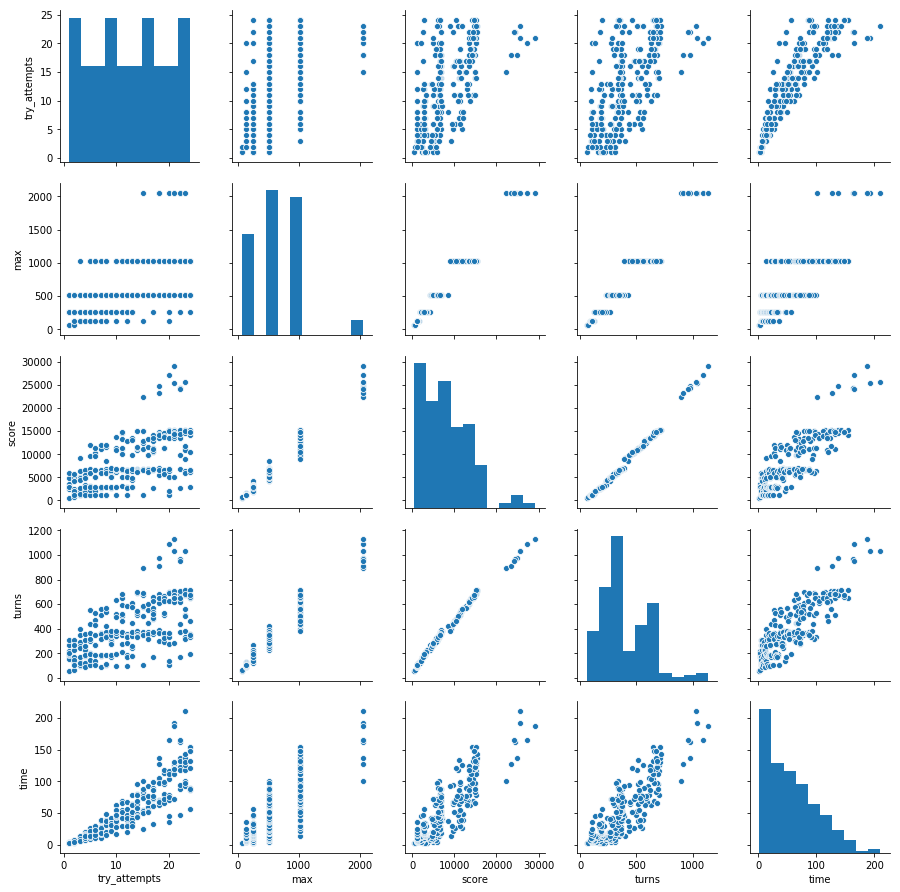

```python
sns.pairplot(pd.read_excel('April 22.xlsx').drop(columns=['loop', 'game_id']))
```

In the above pairplot the scatter plot between score and try_attempts appears to have 'levels' or areas where it plateus. Looking at the score and max plot it appears that the 'levels' are associated with what was the max number the game reached.

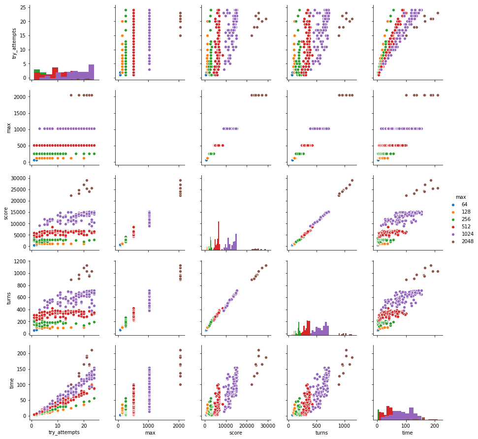

```python
sns.pairplot(pd.read_excel('April 22.xlsx').drop(columns=['loop', 'game_id']), diag_kind='hist', hue='max')
```

Coloring the visual by max provides a lot of insight.

A few areas to explore: The best one move that generates the highest score.

Playthrough of 'x' games to determine the highest scoring direction to go.

Will an 'infite' increase in the number of 'try_attempts' continue to generate a higher 'max' number?

Does the number of 'empty' squares matter?